# Covid19 Analysis

### 3.3.5 Computing the mean square errors and finding the best predictors

For numerical data like this, the most appropriate measure of accuracy is the Root Mean Square Error (RMSE).

Given two vectors of numbers $X=(x_1,x_2, ... x_n)$ and $Y=(y_1,y_2,..., y_n)$ let’s say the test set, and the prediction values, the “distance” between them is computed as follows:
$$RMSE(X,Y)=\sqrt{\frac{\sum_{i=1}^n
(x_i-y_i)^2}{n}}$$

The closer that distance is to zero the better it is.

THe following code creates an empty dataframe to store the results for the RMSE computations for each predictive model.

```r
RMSE = matrix(0, nrow = 1, ncol = ncol(results) - 2)
RMSE = as.data.frame(RMSE)
colnames(RMSE) = colnames(results[, 3:ncol(results)])
for (i in 1:ncol(RMSE)) {
    RMSE[1, i] = rmse(results[, 2], results[, i + 2], na.rm = TRUE)
}
write.csv(RMSE, paste0("../Results/", df1$Date[nrow(df1)], "/Smoothed_7_RMSE_days_",
    k, "_Cases.csv"))
RMSE
```

| PredNN | PredAutoNN | PredAutoARIMA | PredARIMA | Ensemble1 | Ensemble2 |
| --- | --- | --- | --- | --- | --- |
| 327 | 1920 | 514 | 521 | 1179 | 768 |

The output RMSE matrix is saved as a csv file in the newly created Results folder.

### 3.3.6 Graphing The results with important dates

The following set’s up dates that were important in Louisiana.

```r
geom.text.size = 4
theme.size = (14/5) * geom.text.size
Lck = as.Date("2020-03-22")
Ph2 = Lck + 74
Msk = Lck + 111
ScOpen = Lck + 151
Ph3 = Lck + 177
MPh2 = Lck + 248
Vac = Lck + 288
Ph3N = Lck + 346
```

The ggplot here is quite involving since it contains all the basic moves the Louisiana government did.

```r
p1 = ggplot(df1, aes(x = Date, y = Cases_ma)) + geom_point(size = 0.5) + geom_line(data = df1,
    aes(x = Date, y = Cases_ma, colour = "Actual Values")) + geom_line(data = results,
    aes(x = Date, y = PredARIMA, colour = "ARIMA Predictions")) + geom_text(x = Lck,
    y = 1800, label = "Lockdown", colour = "red", size = geom.text.size) + geom_vline(xintercept = Lck,
    linetype = 4, colour = "red") + geom_text(x = Ph2, y = 1000, label = "Phase 2 Reopening",
    colour = "green", size = geom.text.size) + geom_vline(xintercept = Ph2, linetype = 4,
    colour = "green") + geom_text(x = Msk, y = 1500, label = "Mask Mandate", colour = "red",
    size = geom.text.size) + geom_vline(xintercept = Msk, linetype = 4, colour = "red") +
    geom_text(x = ScOpen, y = 1300, label = "Schools Open", colour = "green", size = geom.text.size) +
    geom_vline(xintercept = ScOpen, linetype = 4, colour = "green") + geom_text(x = Ph3,
    y = 300, label = "Phase 3 Reopening", colour = "green", size = geom.text.size) +
    geom_vline(xintercept = Ph3, linetype = 4, colour = "green") + geom_text(x = MPh2,
    y = 1100, label = "Modified Phase 2", colour = "green", size = geom.text.size) +
    geom_vline(xintercept = MPh2, linetype = 4, colour = "green") + geom_text(x = Vac,
    y = 800, label = "Vaccinations Started", colour = "red", size = geom.text.size) +
    geom_vline(xintercept = Vac, linetype = 4, colour = "red") + geom_text(x = Ph3N,
    y = 1100, label = "Phase 3", colour = "green", size = geom.text.size) + geom_vline(xintercept = Ph3N,
    linetype = 4, colour = "green") + scale_x_date(breaks = "1 month", date_labels = "%b") +
    ylab("Daily Cases") + ggtitle(paste0("MA(7) Smoothed Timeseries of Covid19 Cases in Louisiana with ",
    h, " days prediction")) + theme_bw() + theme(axis.text = element_text(size = theme.size,
    colour = "black")) + theme(legend.title = element_blank())
```

The following code saves the graph at the designated folder with specific width and height. This is very useful, especially if this is in a google repository where the link can be embedded on a webpage, and re-newed at will

```r
ggsave(paste0("../Results/", df1$Date[nrow(df1)], "/Smoothed_With_", h, "_days_prediction_Cases.jpg"),
    width = 12, heigh = 8, p1)
ggsave(paste0("../Results/Latest_Smoothed_With_", h, "_days_prediction_Cases.jpg"),
    width = 12, heigh = 8, p1)
```

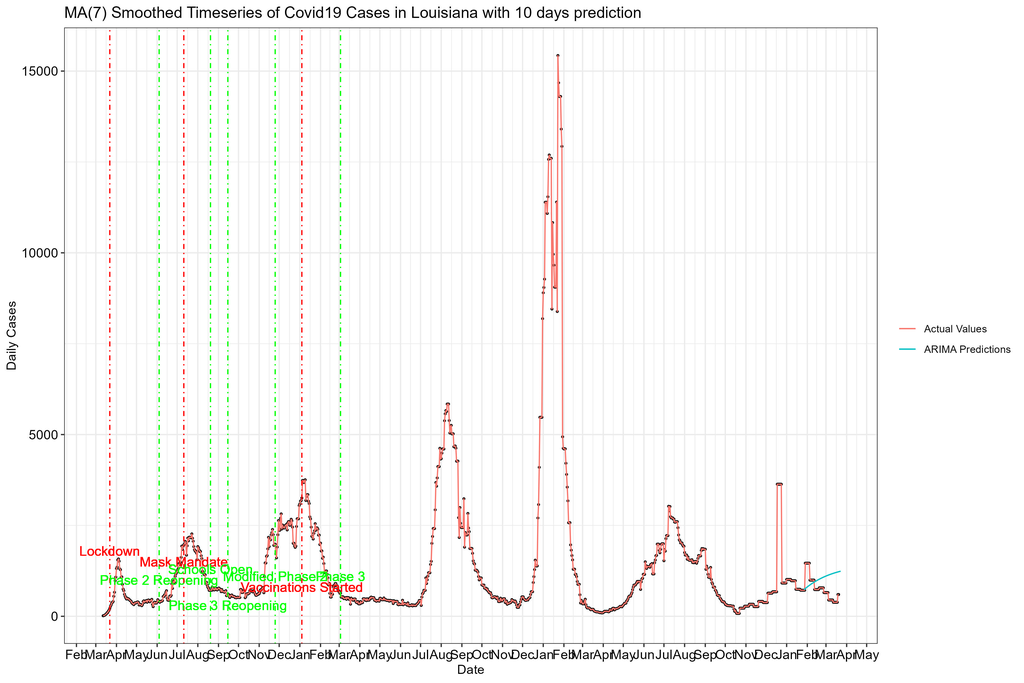

3.Final Graph

# 4 General Forecasting

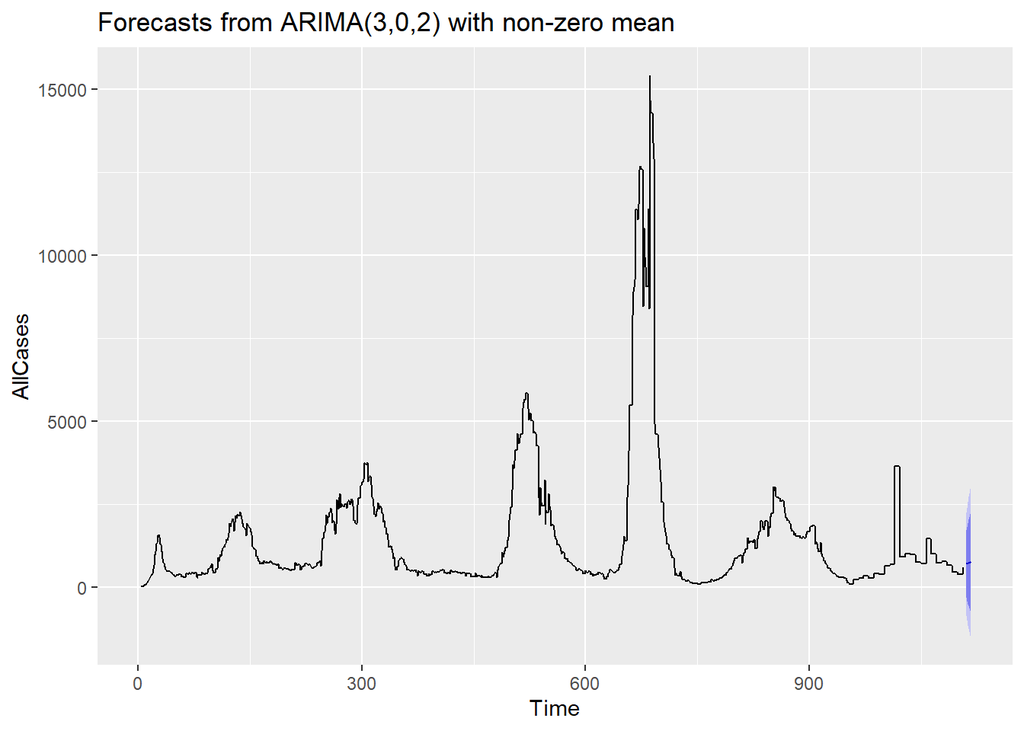

```r
fitfinal = auto.arima(AllCases)
forfinal = forecast(fitfinal, h = 7)
autoplot(forfinal)
```

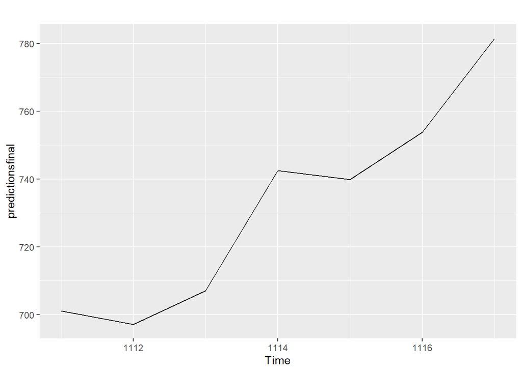

```r
predictionsfinal = forfinal$mean
autoplot(predictionsfinal)
```